# Naive Bayes Assignment

### The purpose of this assignment is to use Naive Bayes for classification. Here we will:

#### • Use Naive Bayes classification to complete the task.

#### • Make predictions from your model.

### Loading all the libraries we will need for the classification.

```r
library(caret)
library(ISLR)
library(e1071)
library(gmodels)
library(dplyr)
library(naivebayes)
library(corrplot)
library(car)
library(pROC)
library(epiDisplay)
```

### Loading the dataset and then choosing just the data we need for our classification.

```r
rm(list = ls(all=T))


FlightData <- read.csv("C:\\Users\\akash\\Desktop\\Kent - !st Sem\\RPractice\\FlightDelays.csv")

# Database we need.

FlightData_f <- dplyr::select(FlightData, DAY_WEEK, CRS_DEP_TIME, ORIGIN, DEST, CARRIER, Flight.Status)

head(FlightData_f)
```

```
##   DAY_WEEK CRS_DEP_TIME ORIGIN DEST CARRIER Flight.Status
## 1        4         1455    BWI  JFK      OH        ontime
## 2        4         1640    DCA  JFK      DH        ontime
## 3        4         1245    IAD  LGA      DH        ontime
## 4        4         1715    IAD  LGA      DH        ontime
## 5        4         1039    IAD  LGA      DH        ontime
## 6        4          840    IAD  JFK      DH        ontime
```

### Look at the data and check for nulls and look at the summary.

```r
colSums(is.na(FlightData_f))
```

```
##      DAY_WEEK  CRS_DEP_TIME        ORIGIN          DEST       CARRIER
##             0             0             0             0             0
## Flight.Status
##             0
```

```r
#Let's look at the summary
str(FlightData_f)
```

```
## 'data.frame':    2201 obs. of  6 variables:
##  $ DAY_WEEK     : int  4 4 4 4 4 4 4 4 4 4 ...
##  $ CRS_DEP_TIME : int  1455 1640 1245 1715 1039 840 1240 1645 1715 2120 ...
##  $ ORIGIN       : chr  "BWI" "DCA" "IAD" "IAD" ...
##  $ DEST         : chr  "JFK" "JFK" "LGA" "LGA" ...
##  $ CARRIER      : chr  "OH" "DH" "DH" "DH" ...
##  $ Flight.Status: chr  "ontime" "ontime" "ontime" "ontime" ...
```

### Looking at the summary we realise that DAY_WEEK, CRS_DEP_TIME and Flight.Status are not in the right format.

## Week and Time variables need to be recoded as factors.

### Create time slots and convert the week and time as factors. Assign delayed and ontime as 1 and 0.

```r
FlightData_f$DAY_WEEK<- as.factor(FlightData_f$DAY_WEEK)

FlightData_f$CRS_DEP_TIME <- recode(FlightData_f$CRS_DEP_TIME, "600:630=1;
       631:700=2;
       701:730=3;
       731:800=4;
       801:830=5;
       831:900=6;
       901:930=7;
       931:1000=8;
       1001:1030=9;
       1031:1100=10;
       1101:1130=11;
       1131:1200=12;
       1201:1230=13;
       1231:1300=14;
       1301:1330=15;
       1331:1400=16;
       1401:1430=17;
       1431:1500=18;
       1501:1530=19;
       1531:1600=20;
       1601:1630=21;
       1631:1700=22;
       1701:1730=23;
       1731:1800=24;
       1801:1830=25;
       1831:1900=26;
       1901:1930=27;
       1931:2000=28;
       2001:2030=29;
       2031:2100=30;
       2101:2130=31;
       2131:2200=32;

       else=NA")

FlightData_f$CRS_DEP_TIME<- as.factor(FlightData_f$CRS_DEP_TIME)

#Converting Flight.Status into 1 - delayed, 0 - ontime

FlightData_f$Flight.Status [FlightData_f$Flight.Status=='ontime']<-0
FlightData_f$Flight.Status [FlightData_f$Flight.Status=='delayed']<-1


FlightData_f$Flight.Status<-as.factor(FlightData_f$Flight.Status)


#Now let's see how the summary looks:
summary(FlightData_f)
```

```
##  DAY_WEEK  CRS_DEP_TIME     ORIGIN              DEST
##  1:308    18     : 215   Length:2201        Length:2201
##  2:307    14     : 201   Class :character   Class :character
##  3:320    6      : 173   Mode  :character   Mode  :character
##  4:372    23     : 167
##  5:391    2      : 135
##  6:250    22     : 131
##  7:253    (Other):1179
##    CARRIER          Flight.Status
##  Length:2201        0:1773
##  Class :character   1: 428
##  Mode  :character
##
##
##
##
```

### Now We Know That All The Data is Categorical.

### Let’s plot the histogram now and see what it looks like.

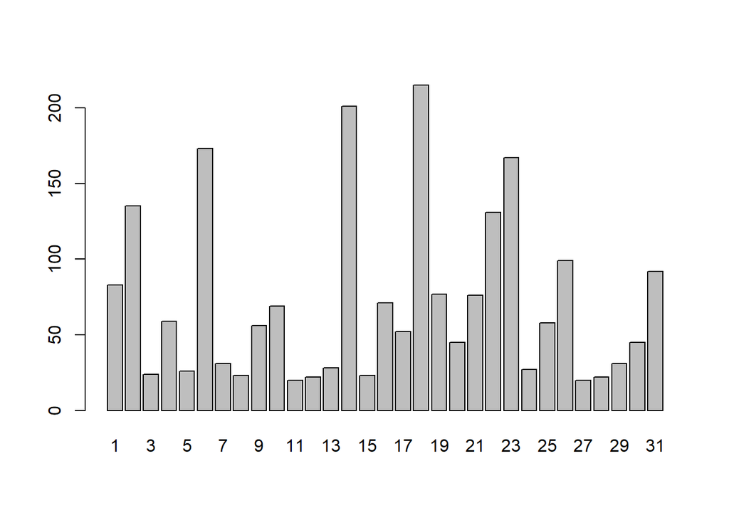

```r
barplot(table(FlightData_f$CRS_DEP_TIME))
```

# Part 1:Divide the data into 60% training and 40% validation

```r
set.seed(123)
#Divide data into 40% test and 60% train
Index_Train<-createDataPartition(FlightData_f$Flight.Status, p=0.6, list=FALSE)
Train <-FlightData_f[Index_Train,]
Test  <-FlightData_f[-Index_Train,]
```

# Part 2: Now, run the Naive Bayes model, and predict Flight status on the test set

```r
# Build a naïve Bayes classifier
set.seed(123)
nb_model <-naiveBayes(Flight.Status~DAY_WEEK+ CRS_DEP_TIME + ORIGIN + DEST + CARRIER,data = Train)
nb_model
```

```
##
## Naive Bayes Classifier for Discrete Predictors
##
## Call:
## naiveBayes.default(x = X, y = Y, laplace = laplace)
##
## A-priori probabilities:
## Y
##         0         1
## 0.8054504 0.1945496
##
## Conditional probabilities:
##    DAY_WEEK
## Y            1          2          3          4          5          6
##   0 0.13909774 0.14473684 0.14003759 0.17669173 0.18045113 0.10996241
##   1 0.17509728 0.16731518 0.14785992 0.15175097 0.17898833 0.04669261
##    DAY_WEEK
## Y            7
##   0 0.10902256
##   1 0.13229572
##
##    CRS_DEP_TIME
## Y             1           2           3           4           5           6
##   0 0.044172932 0.068609023 0.011278195 0.024436090 0.012218045 0.086466165
##   1 0.019455253 0.073929961 0.003891051 0.015564202 0.011673152 0.046692607
##    CRS_DEP_TIME
## Y             7           8           9          10          11          12
##   0 0.017857143 0.011278195 0.020676692 0.035714286 0.011278195 0.012218045
##   1 0.000000000 0.000000000 0.015564202 0.019455253 0.003891051 0.000000000
##    CRS_DEP_TIME
## Y            13          14          15          16          17          18
##   0 0.012218045 0.093045113 0.014097744 0.035714286 0.024436090 0.081766917
##   1 0.003891051 0.093385214 0.007782101 0.019455253 0.031128405 0.120622568
##    CRS_DEP_TIME
## Y            19          20          21          22          23          24
##   0 0.033834586 0.021616541 0.036654135 0.062969925 0.064849624 0.013157895
##   1 0.054474708 0.031128405 0.031128405 0.042801556 0.132295720 0.000000000
##    CRS_DEP_TIME
## Y            25          26          27          28          29          30
##   0 0.028195489 0.031015038 0.008458647 0.010338346 0.014097744 0.018796992
```

[output cut: 9 more lines]

```
##   1 0.09727626 0.50583658 0.39688716
##
##    DEST
## Y         EWR       JFK       LGA
##   0 0.2998120 0.1701128 0.5300752
##   1 0.3813230 0.1712062 0.4474708
##
##    CARRIER
## Y           CO         DH         DL         MQ         OH         RU
##   0 0.04135338 0.24530075 0.18703008 0.11748120 0.01315789 0.17763158
##   1 0.07392996 0.33852140 0.07392996 0.18677043 0.01167315 0.20233463
##    CARRIER
## Y           UA         US
##   0 0.01597744 0.20206767
##   1 0.01167315 0.10116732
```

## Here we can see that there is 80% Probability that the flight is ontime and 20% probability that the flight is delayed.

# Predicting the model on test set

```r
set.seed(123)
Test_labels <-predict(nb_model,Test, type= "raw")
head(Test_labels)
```

```
##              0          1
## [1,] 0.6644461 0.33555389
## [2,] 0.7598018 0.24019822
## [3,] 0.7262698 0.27373025
## [4,] 0.9125790 0.08742096
## [5,] 0.9829496 0.01705042
## [6,] 0.9351171 0.06488285
```

# Part 3 Output both a counts table and a proportion table outlining how many and what proportion of flights were delayed and on-time at each of the three airports.

### Getting the Count Table and Probability Table for Train Set

```r
(table(Train$ORIGIN, Train$Flight.Status))
```

```
##
##         0   1
##   BWI  56  25
##   DCA 684 130
##   IAD 324 102
```

```r
prop.table((table(Train$ORIGIN, Train$Flight.Status)))
```

```
##
##                0          1
##   BWI 0.04239213 0.01892506
##   DCA 0.51778955 0.09841030
##   IAD 0.24526874 0.07721423
```

### We can see that 130 flights that originated from DCA were delayed.

### The probability of a flight being delayed which originated from DCA is the highest.

### Getting the Count Table and Probability Table for Test Set

```r
(table(Test$ORIGIN, Test$Flight.Status))
```

```
##
##         0   1
##   BWI  52  12
##   DCA 465  91
##   IAD 192  68
```

```r
prop.table((table(Test$ORIGIN, Test$Flight.Status)))
```

```
##
##                0          1
##   BWI 0.05909091 0.01363636
##   DCA 0.52840909 0.10340909
##   IAD 0.21818182 0.07727273
```

### We can see the same trend in our test set.

# Part 4 Output the confusion matrix and ROC for the validation data (test set)

### Let’s build the ROC

```r
#Passing the second column of the predicted probabilities
#That column contains the probability associated to ‘yes’
roc(Test$Flight.Status, Test_labels[,2])
```

```
##
## Call:
## roc.default(response = Test$Flight.Status, predictor = Test_labels[,     2])
##
## Data: Test_labels[, 2] in 709 controls (Test$Flight.Status 0) < 171 cases (Test$Flight.Status 1).
## Area under the curve: 0.6749
```

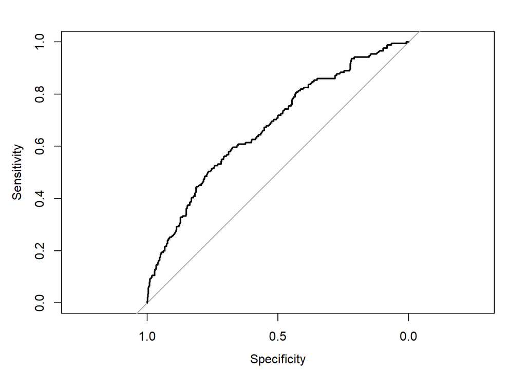

```r
plot.roc(Test$Flight.Status,Test_labels[,2])
```

### For the CrossTable, we need to Predict again with Type as Class

```r
#Predicting the model on test set with type as class
set.seed(123)
Test_labels1 <-predict(nb_model,Test, type= "class")
head(Test_labels1)
```

```
## [1] 0 0 0 0 0 0
## Levels: 0 1
```

```r
#Building the crosstable for the test set.

set.seed(123)
CrossTable(x=Test$Flight.Status,y=Test_labels1, prop.chisq = FALSE)
```

```
##
##
##    Cell Contents
## |-------------------------|
## |                       N |
## |           N / Row Total |
## |           N / Col Total |
## |         N / Table Total |
## |-------------------------|
##
##
## Total Observations in Table:  880
##
##
##                    | Test_labels1
## Test$Flight.Status |         0 |         1 | Row Total |
## -------------------|-----------|-----------|-----------|
##                  0 |       683 |        26 |       709 |
##                    |     0.963 |     0.037 |     0.806 |
##                    |     0.824 |     0.510 |           |
##                    |     0.776 |     0.030 |           |
## -------------------|-----------|-----------|-----------|
##                  1 |       146 |        25 |       171 |
##                    |     0.854 |     0.146 |     0.194 |
##                    |     0.176 |     0.490 |           |
##                    |     0.166 |     0.028 |           |
## -------------------|-----------|-----------|-----------|
##       Column Total |       829 |        51 |       880 |
##                    |     0.942 |     0.058 |           |
## -------------------|-----------|-----------|-----------|
##
##
```